# Tarea 6

Diego Abarca, Fernando Carmona

2024-12-4

```r
library(ggpubr)
library("BSDA")
```

# *tarea 6:*

### a) Defina las hipótesis a contrastar.

Como la hipótesis planteada es que el mejor tiempo medio de los atletas de raza oriental antes de ingresar al programa de entrenamiento era de 19,4 segundos. Ho = 19.4seg

La hipótesis alternativa será que el mejor tiempo medio de los atletas de raza oriental antes del programa, no es igual a 19,4 segundos. Ha != 19.4 seg

```r
Test_Velocidad_Oriental <- read.csv2("data.csv")

Test_Velocidad_Oriental =  Test_Velocidad_Oriental[Test_Velocidad_Oriental$Raza =="Oriental",]

AntesDelEntrenamiento = Test_Velocidad_Oriental[,3]
```

### b) Proponga un procedimiento adecuado para el análisis.

Primero analizar que tipo de test es el adecuado para analizar la vericidad de la afirmación que se muestra en el enucniado. para eso primero analizamos los datos que tenemos:

#### 1) Análisis de la distribución de los datos

El primer paso es determinar qué tipo de distribución siguen los datos del conjunto de datos denominado “Test_Velocidad_Oriental”. Para ello, aplicamos el test de Shapiro-Wilk (shapiro.test) y complementamos el análisis con la visualización generada por un QQ-plot.

```r
v.test <- shapiro.test(AntesDelEntrenamiento)
v.test
```

```
##
##  Shapiro-Wilk normality test
##
## data:  AntesDelEntrenamiento
## W = 0.98354, p-value = 0.932
```

El valor del p-value resultante es mayor a 0.05, lo que sugiere que los datos siguen probablemente una distribución normal. El test de Shapiro-Wilk evalúa la hipótesis nula de que los datos provienen de una distribución normal, y dado que no rechazamos esta hipótesis, concluimos que la distribución es probablemente normal. Esta conclusión se refuerza aún más con la gráfica generada a continuación.

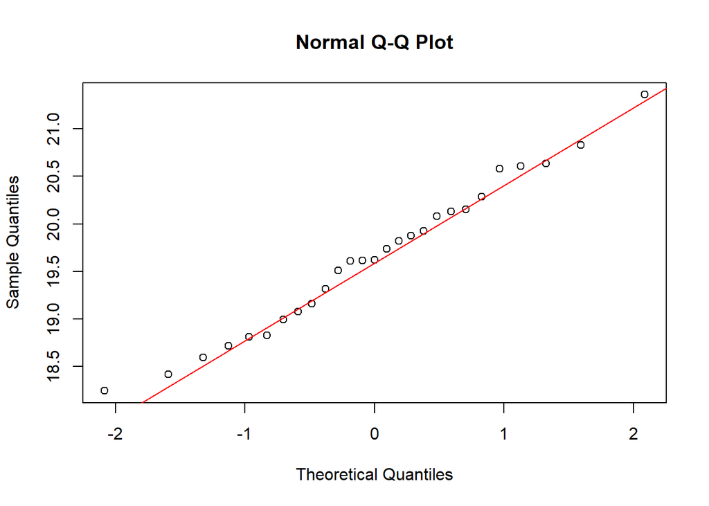

```r
# QQ-plot
qqnorm(AntesDelEntrenamiento)
qqline(AntesDelEntrenamiento, col = "red")  # Agregar la línea de referencia
```

Como se puede observar, los puntos en el gráfico siguen una línea de tendencia recta, lo que hace más probable que los datos sigan una distribución normal.

#### 2) Tamaño de la muestra y conocimiento sobre la varianza

El siguiente paso es verificar el tamaño de la muestra y determinar si conocemos la varianza poblacional o muestral. En este caso, sabemos que la muestra tiene menos de 30 datos y que se conoce la varianza poblacional.

#### Conclusión del análisis

Con estos análisis en mano, podemos concluir que el test adecuado para analizar la veracidad de la afirmación es el Z-test. Esto es posible porque cumplimos con todas las condiciones necesarias: la muestra es pequeña (menos de 30 datos), conocemos la varianza poblacional y los datos siguen una distribución normal.

### C) Verifique las condiciones necesarias del procedimiento y ejecútelo.

#### Datos:

$\tilde{X}$ = 19.4

μ = ¿?

σ = $\sqrt{4}$

n = 27

```r
velocidad.z <- z.test(x = AntesDelEntrenamiento, mu = 19.4, sigma.x = 2)
velocidad.z
```

```
##
##  One-sample z-Test
##
## data:  AntesDelEntrenamiento
## z = 0.64904, p-value = 0.5163
## alternative hypothesis: true mean is not equal to 19.4
## 95 percent confidence interval:
##  18.89542 20.40421
## sample estimates:
## mean of x
##  19.64981
```

μ = 19.64981

### D) Interprete los resultados obtenidos en el contexto del problema.

El intervalo de confianza es:

```r
MediaMuestral = 19.64981

Z_alpha_2 = 1.96

SD = 2

n = 27

IC1 = MediaMuestral + Z_alpha_2*(SD/sqrt(n))

IC2 = MediaMuestral - Z_alpha_2*(SD/sqrt(n))

cat("El intervalo de confianza es: [", IC2,",",IC1,"]")
```

```
## El intervalo de confianza es: [ 18.89541 , 20.40421 ]
```

### E)

Como obtuvimos que el promedio (μ) es distinto de 19.4, pero la diferencia esta dentro del intervalo de confianza, por tanto, aceptamos la hipótesis nula. Sabiendo que el promedio real (μ) es igual a 19.64, lo que cae dentro del intervalo de confianza, podemos concluir que el promedio es igual a 19.4 con un intervalo de confianza de 95% por tanto se trata como verdadera la afirmación del comité olímpico.